# R Notebook

```r
library(tidyverse)
library(janitor)
library(animation)
library(factoextra)
library(cluster)
library(broom)
library(corrplot)
library(GGally)
shopping_data <- read_csv("data/mall_customers.csv") %>% clean_names()
```

Q1. You have been provided some customer data from a shopping centre. Do some exploratory analysis on the data. Comment on findings.

```r
glimpse(shopping_data)
```

```
Rows: 200
Columns: 5
$ customer_id          <dbl> 1, 2, 3, 4, 5, 6, 7, 8, 9, 10, 11, 12, 13, 14, 15, 16, 17, 18, 19, 20, 21…
$ gender               <chr> "Male", "Male", "Female", "Female", "Female", "Female", "Female", "Female…
$ age                  <dbl> 19, 21, 20, 23, 31, 22, 35, 23, 64, 30, 67, 35, 58, 24, 37, 22, 35, 20, 5…
$ annual_income_k      <dbl> 15, 15, 16, 16, 17, 17, 18, 18, 19, 19, 19, 19, 20, 20, 20, 20, 21, 21, 2…
$ spending_score_1_100 <dbl> 39, 81, 6, 77, 40, 76, 6, 94, 3, 72, 14, 99, 15, 77, 13, 79, 35, 66, 29, …
```

*Looks like there aren’t too many variables, with customer id being redundant. Guessing that the biggest co-efficient will exist between spending_score and annual_income, then spending_score and age and then not quite sure if we are going to get any other significant corelations.*

```r
#Like this by the way, nice quick trick
any(is.na(shopping_data))
```

```
[1] FALSE
```

*Nice, so no missing values. Now, I’m going to turn our single character variable into a factor*

```r
shopping_data_clean <- shopping_data %>%
  mutate(gender = as.factor(gender))
```

Q2. We are interested in creating a marketing campaign to target customers based on their spending score and annual income. Perform a k-means clustering to find if there are meaningful clusters in the data to target the customers.

*I’m guessing that we don’t really need any sort of index, but if we can just hold onto the numbering by putting them into rownames, we may as well*

```r
shopping_data_clean <-
shopping_data_clean %>%
  column_to_rownames("customer_id")
```

*Gonna have a little look at the correlation, but first scaling*

```r
shopping_data_scale <-
shopping_data_clean %>%
  mutate_if(is.numeric, scale)
```

*Maybe a quick bit of ggpairs on this as well*

```r
ggpairs(shopping_data_clean)
```

[output not shown]

*Let’s have a look at the corrplot as well, it would be good to double-check that these two basically can show the same thing*

```r
corrplot(cor(shopping_data_scale), method = "number", type = "lower")
```

```
Error in cor(shopping_data_scale) : 'x' must be numeric
```

```r
shopping_scale_all_num <-
shopping_data_scale %>%
  mutate(male = as.integer(gender) - 1) %>%
  select(-gender)
```

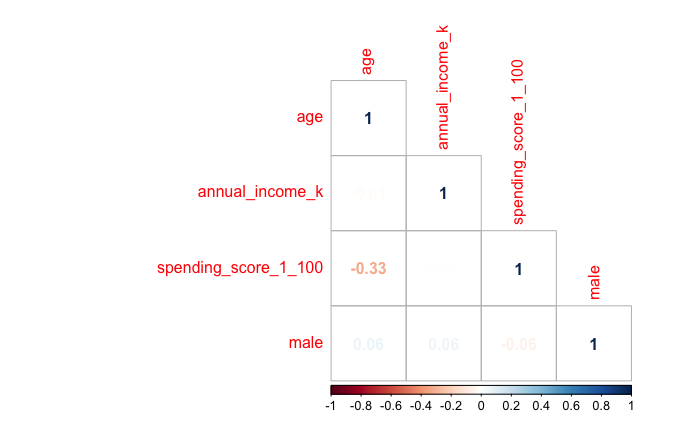

```r
corrplot(cor(shopping_scale_all_num), method = "number", type = "lower")
```

```r
clustered_shopping <- kmeans(shopping_scale_all_num,
                            centers = 10,
                            nstart = 30)
```

Q3. Perform k-means clustering and chose a value of k.

```r
max_k = 20

shopping_k_clusters <- tibble(k = 1:max_k) %>%
  mutate(
    kclust = map(k, ~ kmeans(shopping_scale_all_num, .x, nstart = 30)),
    tidied = map(kclust, tidy),
    glanced = map(kclust, glance),
    augmented = map(kclust, augment, shopping_data_clean)
  )

shopping_k_clusters
```

| k | kclust | tidied | glanced | augmented |
| --- | --- | --- | --- | --- |
| 1 |  |  |  |  |
| 2 |  |  |  |  |
| 3 |  |  |  |  |
| 4 |  |  |  |  |
| 5 |  |  |  |  |
| 6 |  |  |  |  |
| 7 |  |  |  |  |
| 8 |  |  |  |  |
| 9 |  |  |  |  |
| 10 |  |  |  |  |

[output cut: 10 more lines]

*Right, going to try get an elbow point now*

```r
shopping_clusterings <- shopping_k_clusters %>%
  unnest(glanced)

shopping_clusterings
```

| k | kclust | tidied | totss | tot.withinss | betweenss | iter | augmented |
| --- | --- | --- | --- | --- | --- | --- | --- |
| 1 |  |  | 646.28 | 646.28000 | 1.932676e-12 | 1 |  |
| 2 |  |  | 646.28 | 436.57548 | 2.097045e+02 | 1 |  |
| 3 |  |  | 646.28 | 342.92937 | 3.033506e+02 | 3 |  |
| 4 |  |  | 646.28 | 253.25678 | 3.930232e+02 | 3 |  |
| 5 |  |  | 646.28 | 215.94109 | 4.303389e+02 | 2 |  |
| 6 |  |  | 646.28 | 181.28199 | 4.649980e+02 | 5 |  |
| 7 |  |  | 646.28 | 164.12481 | 4.821552e+02 | 4 |  |
| 8 |  |  | 646.28 | 149.70026 | 4.965797e+02 | 4 |  |
| 9 |  |  | 646.28 | 139.68277 | 5.065972e+02 | 3 |  |
| 10 |  |  | 646.28 | 127.64722 | 5.186328e+02 | 4 |  |

[output cut: 10 more lines]

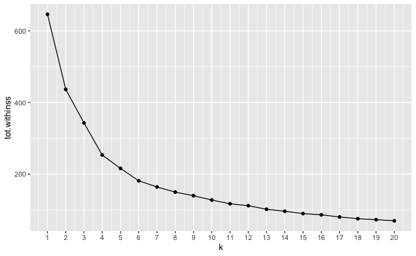

```r
ggplot(shopping_clusterings, aes(x=k, y=tot.withinss)) +
  geom_point() +
    geom_line() +
    scale_x_continuous(breaks = seq(1, 20, by = 1))
```

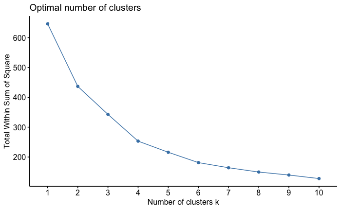

```r
fviz_nbclust(shopping_scale_all_num,
             kmeans,
             method = "wss",
             nstart = 25)
```

*Looking at the above, i’d say it’s either 2 or 4 at this stage. Will try another couple of the methods.*

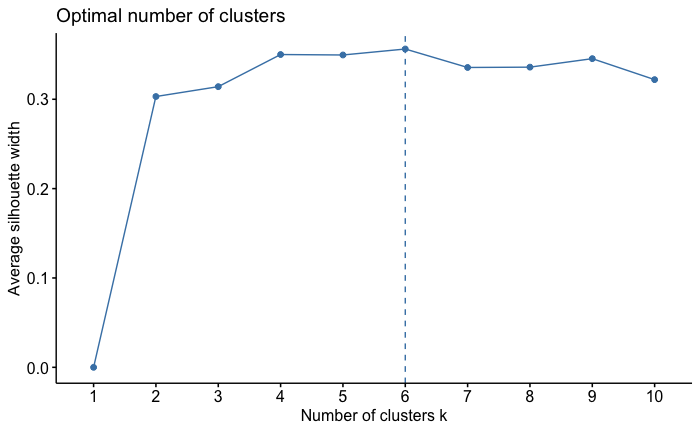

```r
fviz_nbclust(shopping_scale_all_num,
             kmeans,
             method = "silhouette",
             nstart = 25)
```

*So 6 is showing up as the maximum but going by our previous checks, I’d say 4 is the number of clusters we should go for*

Q4. Visualise the clustering for your chosen value of k.

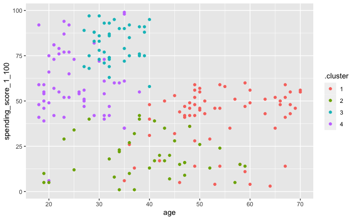

```r
chosen_4_cluster <-
 shopping_clusterings %>%
  unnest(cols = c(augmented)) %>%
  filter(k == 4)

#Going to plot age and spending_score as these seemed like the two most closely correlated
chosen_4_cluster %>%
 ggplot(aes(x = age, y = spending_score_1_100, colour = .cluster)) +
  geom_point(aes(color = .cluster))
```

```r
NA
```

Q5. Do you think the clustering seems a good fit for this data? Q6. Comment on the attributes on one or two of the clusters (maybe even give them a label if you like - like in section 4.1 of the ‘Segmentation & clustering intro’ lesson).

**Looking at this particular example, I’d say it’s a reasonably good fit. It seems to tell a story of 4 quite distinct groups.**

*1. Slow and steadies* - mostly middle-aged and above, these individuals tend to spend an average amount in a disciplined manner.

*2. Systematic thrifties not just in their fifties* - A group who tend not to spend very much in the mall, no matter what their age is.